# Report

Shreysa Sharma, Jashangeet Singh

10/25/2017

Code Repository: https://github.ccs.neu.edu/pdpmr-f17/a6-jashangeet-shreysa.git

#### Specifications of host execution Environment

| Attribute | Value |
| --- | --- |
| Java Version | 1.8.0_102 |
| Java(TM) SE Runtime Environment | (build 1.8.0_102-b14) |
| Java HotSpot(TM) 64-Bit Server VM | (build 25.102-b14, mixed mode) |
| Model Identifier | MacBookPro11,2 |
| Processor Name | Intel Core i7 |
| Processor Speed | 2.2 GHz |
| Number of Processors | 1 |
| Total Number of Cores | 4 |
| L2 Cache (per Core) | 256 KB |
| L3 Cache | 6 MB |
| Memory | 16 GB |

### Summary of the design of evaluated program

The implementation involves reading the data and putting it in SparkContext. Cleaning the data by putting various validity checks and then using maps, filters and other functions availabe in scala to get the desired output.

### Performance Analysis

#### Table 1: Time taken for 10 runs on small dataset

| Run | total_time | total_avg_time |
| --- | --- | --- |
| 1 | 7 | 5.9 |
| 2 | 6 | 5.9 |
| 3 | 7 | 5.9 |
| 4 | 7 | 5.9 |
| 5 | 6 | 5.9 |
| 6 | 5 | 5.9 |
| 7 | 5 | 5.9 |
| 8 | 5 | 5.9 |
| 9 | 5 | 5.9 |
| 10 | 6 | 5.9 |

The above table represents the total time taken and total average time of 10 runs of Scala job in seconds. Each run takes about 5.9 seconds to finish. These values are for the subset on the assignment page on the local machine.

##### Plot 1: Total time in seconds vs Run for the subset

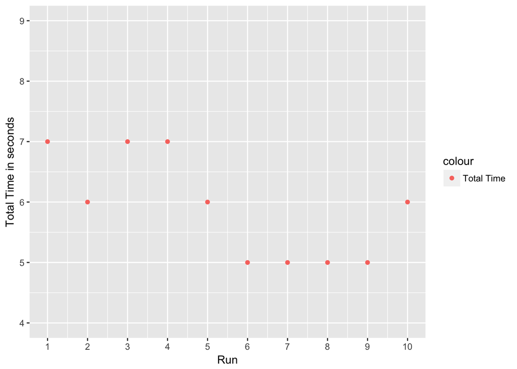

Plot 1 represents the graph for the data shown in table 1. This represnts the total time taken by each run in seconds on the small dataset. It can be seen from the graph that the values range between 5 to 7 seconds averaging out to 5.9 seconds for 10 runs.

#### Table 2: Time taken for 10 runs on complete dataset

| Run | total_time | total_avg_time |
| --- | --- | --- |
| 1 | 100 | 100.6 |
| 2 | 98 | 100.6 |
| 3 | 101 | 100.6 |
| 4 | 99 | 100.6 |
| 5 | 100 | 100.6 |
| 6 | 100 | 100.6 |
| 7 | 102 | 100.6 |
| 8 | 102 | 100.6 |
| 9 | 102 | 100.6 |
| 10 | 102 | 100.6 |

Table 2 represents the total time taken and total average time of 10 runs of Scala job in seconds for the complete dataset. Each run takes about 100.6 seconds to finish.

##### Plot 2: Total time in seconds vs Run for the big dataset

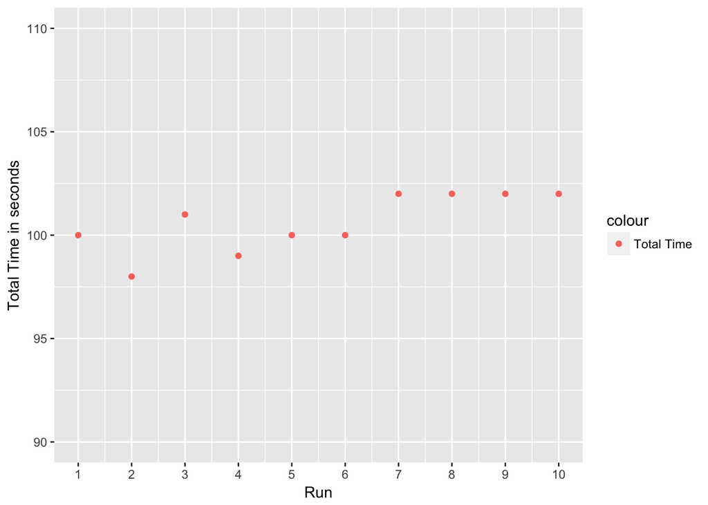

Plot 2 represents the graph for the data shown in table 2. This represnts the total time taken by each run in seconds on the complete dataset. It can be seen from the graph that the values range between 98 to 102 seconds averaging out to 100.6 seconds for 10 runs.

[output not shown]

The above table represents the total time taken by Scala job in seconds. These values are for the subset on the assignment page on EMR.

[output not shown]

The above table represents the total time taken by Scala job in seconds. These values are for the full dataset on EMR.

## Data Analysis

#### Assumptions

For loudness of song, the closer the loudness score to 0 in negative, the louder the song. If value is 0, then it is an invalid entry. We have taken the Song Id, Song Name and Loudness score combination to represent the loudness score. This combination is unique. So if there is a song with same id and same name but different loudness score or any of the other combinations it would appear as a distinct entry in the list.

For longness of song, the duration should be greater than 0, the larger the value, longer is the song. We have taken the Song Id, Song Name and duration combination to represent the longest songs. This combination is unique.

For fastness of song, the larger the value of tempo, the faster is the song. We have taken the Song Id, Song Name and tempo score combination to represent the how fast the song is. This combination is unique.

For artist familiarity, the higher the value from 0, the more is the score. If value is 0 or less than 0, record is invalid We have taken artist name, artist id and artist familiarity score combination to represent the artist familiarity. This combination is unique. So if there is an artist with same id but different name and different familiarity score or any of the other combinations it would appear as a distinct entry in the list.

For song hottness and artist hottness the values should be between 0 and 1. Any value less than 0 or greater than 1 is invalid. We have taken song id or artist id, song name or artist name and song hotness or artist hotness score combination to represent the song hotness and artist hotness respectively. This combination is unique. So if there is an artist or a song with same id but different name or different hotness score or any of the other combinations it would appear as a distinct entry in the list.

For the bigger dataset :

#### Number of distinct songs: 999056

#### Number of distinct artists: 44745

#### Number of distinct albums: 149275

#### Top 5 loudest songs:

(Assumption: the Song Id, Song Name and Loudness Score combination is unique)

| Song Id | Song Name | Loudness Score |
| --- | --- | --- |
| SOAKZAH12AB0187EA3 | The Spectre’s Sinister Commandment) | -0.003 |
| SOSKGCK12AC90715B1 | A Body So Warm | -0.009 |
| SOBNOEN12AB018AE49 | Mechanoid 002 | -0.01 |
| SOLPFVW12A8C137059 | Penvag | -0.021 |
| SOMGDNA12AC3DF6A17 | Face the Nation | -0.025 |

#### Top 5 longest songs:

(Assumption: the Song Id, Song Name and duration combination is unique)

| Song Id | Song Name | Duration |
| --- | --- | --- |
| SOOUBST12AC90977B6 | Grounation) | 3034.90567 |
| SOXUCQN12A6D4FC451 | Raag - Shuddha KalyaN | 3033.5995 |
| SOOMVZJ12AB01878EB | Discussion 2 | 3033.44281 |
| SOTNVEE12A8C13F470 | Chapitre Un (a): Toutes Les Histoires | 3032.76363 |
| SOGFXNB12A8C137BE5 | Der Geist des Llano Estacado Ein Spion | 3032.58077 |

#### Top 5 fastest songs:

(Assumption: the Song Id, Song Name and Tempo Score combination is unique)

| Song Id | Song Name | Tempo Score |
| --- | --- | --- |
| SOVVTEZ12AB0184AAB | Beep Beep | 302.3 |
| SOMSJWX12AB017DB99 | Late Nite Lounge: WVIP | 296.469 |
| SOUTBKH12A8C136286 | A Place Called Hope | 285.157 |
| SOEVQJB12AC960DA2C | Bellas Lullaby - Perrier Citron | 284.208 |
| SOTUXOB12AB0188C3A | Troubled Times | 282.573 |

#### Top 5 most familiar artists:

(Assumption: the Artist Name, Artist Id and Familiarity Score combination is unique)

| Artist Name | Artist Id | Familiarity Score |
| --- | --- | --- |
| Akon | ARCGJ6U1187FB4D01F | 1.0 |
| Akon_ San Quinn_ JT the Bigga Figga | ARCGJ6U1187FB4D01F | 1.0 |
| Akon / Eminem | ARCGJ6U1187FB4D01F | 1.0 |
| Akon / Styles P | ARCGJ6U1187FB4D01F | 1.0 |
| Akon / Wyclef Jean | ARCGJ6U1187FB4D01F | 1.0 |

#### Top 5 Hot artists:

(Assumption: the Artist Name, Artist Id and Hotness Score combination is unique)

| Artist Name | Artist Id | Hotness Score |
| --- | --- | --- |
| Daft Punk | ARF8HTQ1187B9AE693 | 0.997066533839045 |
| Daft Punk | ARF8HTQ1187B9AE693 | 0.997004803235357 |
| Black Eyed Peas | ARTDQRC1187FB4EFD4 | 0.982623202516712 |
| Kanye West | ARRH63Y1187FB47783 | 0.972399563931911 |
| Kanye West / Jamie Foxx | ARRH63Y1187FB47783 | 0.972399563931911 |

##### Top 5 hottest songs:

(Assumption: the Song Id, Song Name and Hotness Score combination is unique)

| Song Id | Song Name | Hotness Score |
| --- | --- | --- |
| SOXQYSC12A6310E908 | Bitter Sweet Symphony | 1.0 |
| SOHGFPP12A8AE4624D | White Flag | 1.0 |
| SONQEYS12AF72AABC9 | Mr. Jones | 1.0 |
| SOULTKQ12AB018A183 | Nothin’ On You [feat. Bruno Mars] | 1.0 |
| SOAAXAK12A8C13C030 | Immigrant Song | 1.0 |

##### Top 5 Prolific artists:

[output not shown]

#### Top 5 most popular keys (must have confidence > 0.7):

| Key | Key Confidence |
| --- | --- |
| 7 | 30420 |
| 0 | 28333 |
| 2 | 25845 |
| 9 | 21283 |
| 4 | 15214 |